# 2022-10-21-report

Weekly Report of U.S Hospitals for 2022-10-21

## Data source: U.S. Health and Human Services (HHS) and Center for Medicare and Medicaid (CMS)

### Team Members: Myung Kyung Hyeon, Xi Chen, Sean Tavares

This is a report generated by an automatic reporting system that summarizes the changes in the hospital data in the given week.

### 1. A Summary of Hospital Record Changes

Below is a summary of how many hospital records were loaded in the most recent week, and how that compares to previous weeks.

| Data Loaded | Report Date |
| --- | --- |
| 4985 | 2022-10-21 |
| 4995 | 2022-10-14 |
| 4996 | 2022-10-07 |
| 4997 | 2022-09-30 |
| 4995 | 2022-09-23 |

### 2. Summary of Hospital Beds Available and Used over 5 Most Recent Weeks

Below is a table summarizing the number of adult and pediatric beds available this week, the number used, and the number used by patients with COVID, compared to the 4 most recent weeks.

| Report Date | Adult Beds | Pediatric Beds | Bed Used | COVID Beds |
| --- | --- | --- | --- | --- |
| 2022-09-23 | 2894916 | 277238 | 407170 | 179204 |
| 2022-09-30 | 2913956 | 278633 | 410073 | 168998 |
| 2022-10-07 | 2908258 | 278578 | 411620 | 165825 |
| 2022-10-14 | 2890573 | 277981 | 415275 | 165868 |
| 2022-10-21 | 2904162 | 279175 | 418106 | 168818 |

### 3. Fraction of Beds in Use by Quality Rating

Below is a graph or table summarizing the fraction of beds currently in use by hospital quality rating, so we can compare high-quality and low-quality hospitals

| Overall Quality Rating | Average Fraction of Beds in Use |
| --- | --- |
| 5 | 0.693 |
| 4 | 0.724 |
| 3 | 0.699 |
| 2 | 0.715 |
| 1 | 0.692 |

### 4. Total Beds Occupied per Week

Below is a bar plot showing the total number of hospital beds used per week, over all time, split into all cases and COVID cases.

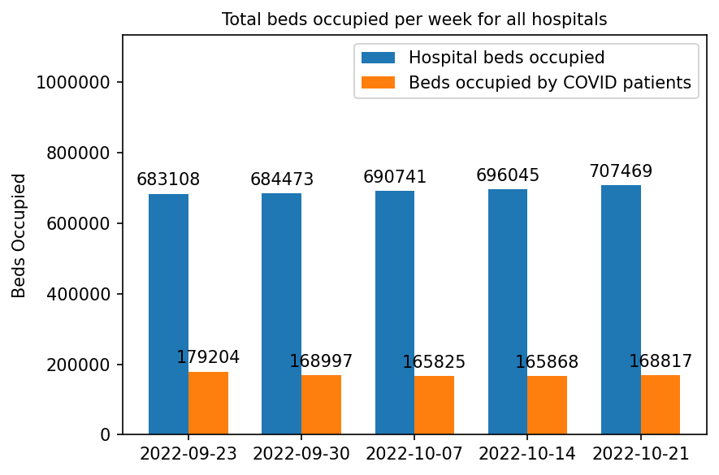

### 5. States with the Largest Increase in Number of COVID Cases from Last Week

Below is a table of the states in which the number of cases has increased by the most since last week.

| Increase in Covid Cases | State |
| --- | --- |
| 809 | IL |
| 524 | OH |
| 444 | WI |
| 440 | NY |
| 436 | MN |

### 6. Hospitals with Largest Changes in COVID Cases

Below is a table of the hospitals (including names and locations) with the largest changes in COVID cases in the last week.

| Hospital Name | Address | City | State | Zip | FIPS Code | Changes in COVID Cases |
| --- | --- | --- | --- | --- | --- | --- |
| CAROLINAS MEDICAL CENTER/BEHAV HEALTH | 1000 BLYTHE BLVD | CHARLOTTE | NC | 28203 | 37119 | 206 |
| NEW YORK-PRESBYTERIAN HOSPITAL | 525 EAST 68TH STREET | NEW YORK | NY | 10065 | 36061 | 173 |
| GEISINGER MEDICAL CENTER | 100 NORTH ACADEMY AVENUE | DANVILLE | PA | 17822 | 42093 | 124 |
| HOUSTON METHODIST HOSPITAL | 6565 FANNIN | HOUSTON | TX | 77030 | 48201 | 113 |
| MAINE MEDICAL CENTER | 22 BRAMHALL ST | PORTLAND | ME | 4102 | 23005 | 111 |

### 7. Hospitals that Did Not Report Data in the Last Week

Below is a table of hospitals that did not report any data in the past week, their names, and the date they most recently reported data.

| Hospital Name | Most Recent Report Date |
| --- | --- |
| ST LUKE'S HOSPITAL | 2022-10-07 |
| JOHNSON COUNTY HEALTHCARE CENTER | 2022-09-30 |
| BLESSING HEALTH KEOKUK | 2022-09-23 |
| FROEDTERT BLUEMOUND REHABILITATION HOSPITAL | 2022-09-30 |

### 8. Top 15 Hospitals with the Highest Number of COVID Inpatients

Below is a table showing the top 15 hospitals with the highest number of COVID inpatients for the requested report week. Hospital name and address are shown below.

Top 15 Hospitals with Highest Number of COVID Inpatient

| Hospital Name | Address | City | State | ZIP | FIPS Code | COVID Inpatient |
| --- | --- | --- | --- | --- | --- | --- |
| CAROLINAS MEDICAL CENTER/BEHAV HEALTH | 1000 BLYTHE BLVD | CHARLOTTE | NC | 28203 | 37119 | 1984 |
| NEW YORK-PRESBYTERIAN HOSPITAL | 525 EAST 68TH STREET | NEW YORK | NY | 10065 | 36061 | 1494 |
| LONG ISLAND JEWISH MEDICAL CENTER | 270 - 05 76TH AVENUE | NEW HYDE PARK | NY | 11040 | 36081 | 1436 |
| ATRIUM HEALTH CABARRUS | 920 CHURCH ST N | CONCORD | NC | 28025 | 37025 | 996 |
| WELLSTAR KENNESTONE REGIONAL MEDICAL CENTER | 677 CHURCH STREET | MARIETTA | GA | 30060 | 13067 | 912 |
| READING HOSPITAL | 420 S 5TH AVENUE | WEST READING | PA | 19611 | 42011 | 887 |
| ATRIUM HEALTH PINEVILLE | 10628 PARK RD | CHARLOTTE | NC | 28210 | 37119 | 860 |
| HOUSTON METHODIST HOSPITAL | 6565 FANNIN | HOUSTON | TX | 77030 | 48201 | 813 |
| AKRON CHILDREN'S HOSPITAL | 1 PERKINS SQUARE | AKRON | OH | 44308 | 39153 | 811 |
| NORTON HOSPITAL / NORTON HEALTHCARE PAVILION / NOR | 200 EAST CHESTNUT STREET | LOUISVILLE | KY | 40202 | 21111 | 759 |
| NORTH SHORE UNIVERSITY HOSPITAL | 300 COMMUNITY DRIVE | MANHASSET | NY | 11030 | 36059 | 743 |
| NYU LANGONE HOSPITALS | 550 FIRST AVENUE | NEW YORK | NY | 10016 | 36061 | 740 |
| ADVENTHEALTH ORLANDO | 601 E ROLLINS ST | ORLANDO | FL | 32803 | 12095 | 686 |
| MOUNT SINAI HOSPITAL | ONE GUSTAVE L LEVY PLACE | NEW YORK | NY | 10029 | 36061 | 674 |
| STATEN ISLAND UNIVERSITY HOSPITAL | 475 SEAVIEW AVENUE | STATEN ISLAND | NY | 10305 | 36085 | 673 |